# Elementos gráficos para Minuta N°1 y Minuta N°2. Análisis de datos de la ventanilla transparencia de la Dirección del Trabajo.

En el documento se analizan los datos sindicales de la ventanilla de transparencia de la Dirección del Trabajo, con el objeto de construir series históricas de la trayectoria de sindicatos y afiliados/as desde 1920 a 2021. Este es el documento de análisis de la información, la versión estilizada y publicada se encuentre en el siguiente link: https://repositoriosindical.netlify.app/

Nicolás Ratto (Repositorio de Estadísticas Sindicales)https://repositoriosindical.netlify.app/  
2021-05-06

```r
library(readxl)
library(tidyverse)
library(lubridate)
library(openxlsx)

colores_res<-c("#090909","#E41657","#9D0CEF","#626262")
```

# 1. Cargar el RData

Se cargan las micro bases elaboradas en el script `01. generacion de microbases mensuales`.

```r
load("../INPUT/basesDT.Rdata")
```

# 2. Definir periodo de análisis

```r
fecha<-data.frame(ano=c(rep(1920:2020,each=12),rep(2021,each=3)),
                  mes=c(rep(1:12,(2020-1920+1)),1,2,3))
```

# 2. Número de sindicatos por año

```r
#### IV. NUMERO DE SINDICATOS ACTIVOS POR AÑO ####

sindicatos<-data.frame(1:nrow(fecha))
for(i in 1:nrow(sindicatos)){

sindicatos[i,1] <- get(
  fecha[i,] %>% mutate(base=paste0("proxy_",ano,"_",mes)) %>% select(base) %>% as.character()
) %>% nrow()

}

sindicatos<-sindicatos %>% cbind(fecha) %>% mutate(fecha=ymd(paste0(ano,"-",mes,"-01"))) %>% rename(sindicatos=X1.nrow.fecha.)
```

Sindicatos activos al 31 de marzo de 2021.

```r
sindicatos %>% filter(ano==2021&mes==3)
```

```
  sindicatos  ano mes      fecha
1      12447 2021   3 2021-03-01
```

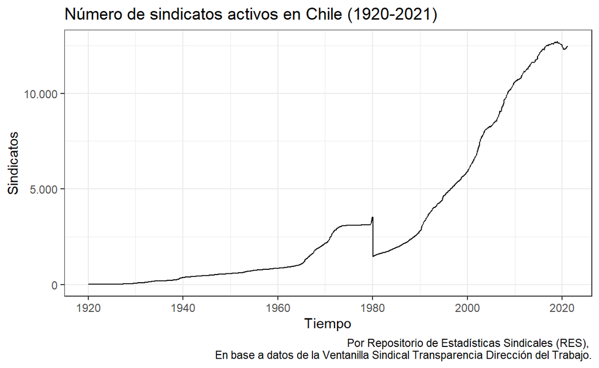

```r
wb <- createWorkbook()
addWorksheet(wb, sheetName = "base mensual sindicatos", gridLines = TRUE)
writeData(wb = wb, sheet = "base mensual sindicatos", x = sindicatos)
firma<-c("Elaborado por Nicolás Ratto para Repositorio de Estadísticas Sindicales (RES): repositoriosindical.netlify.app/",
         "En base a datos de la ventanilla sindical de la Dirección del Trabajo: http://tramites.dirtrab.cl/VentanillaTransparencia/Transparencia/RerporteRRLLOrg.aspx") %>% as.data.frame()
writeData(wb = wb, sheet = "base mensual sindicatos", x = firma,startCol = 9, startRow = 2)
saveWorkbook(wb = wb, file = "../OUTPUT/base mensual sindicatos anidada.xlsx",
             overwrite = TRUE)

sindicatos %>%
  ggplot(aes(x=fecha,y=sindicatos))+geom_line()+theme_bw() +
    scale_y_continuous(labels=function(x) format(x, big.mark = ".", scientific = FALSE)) +
    labs(title = "Número de sindicatos activos en Chile (1920-2021)",
       x="Tiempo",
       y = "Sindicatos",
       caption = "Por Repositorio de Estadísticas Sindicales (RES),
       En base a datos de la Ventanilla Sindical Transparencia Dirección del Trabajo.")
```

```r
ggsave(
  plot = last_plot(),
  filename = "../OUTPUT/Graficos/Nacionales/Grafico1_sindicatos.png",
  device = "png",
  dpi = "retina",
  units = "cm",
  width = 25,
  height = 20
)
```

# 3. Trabajadores y trabajadoras afiliados a sindicatos por año

```r
afiliados<-data.frame(1:nrow(fecha),
                      1:nrow(fecha),
                      1:nrow(fecha))

for(i in 1:nrow(sindicatos)){

  afiliados[i,] <- get(
    fecha[i,] %>% mutate(base=paste0("proxy_",ano,"_",mes)) %>% select(base) %>% as.character()
  ) %>% mutate(afiliados=Socios+Socias) %>% select(Socios, Socias ,afiliados) %>% apply(2,sum)

}


afiliados<-afiliados %>% cbind(fecha) %>% mutate(fecha=ymd(paste0(ano,"-",mes,"-01")))
names(afiliados)<-c("Socios","Socias","Total","ano","mes","fecha")
```

Afiliados a sindicatos activos al 31 de marzo de 2021.

```r
afiliados %>% filter(ano==2021&mes==3)
```

```
  Socios Socias   Total  ano mes      fecha
1 722233 521084 1243317 2021   3 2021-03-01
```

Información sindical para el mes de marzo de 2021.

```r
proxy_2021_3 %>% group_by(Region) %>% tally() %>% arrange(-n)
```

```
# A tibble: 16 x 2
   Region     n
    <dbl> <int>
 1     13  4765
 2      5  1361
 3      8  1222
 4     10   941
 5      2   739
 6      6   538
 7      4   493
 8      7   480
 9      9   390
10      3   353
11      1   247
12     14   235
13     16   208
14     12   163
15     11   162
16     15   150
```

```r
proxy_2021_3 %>% group_by(glosa1) %>% tally() %>% arrange(-n)
```

```
# A tibble: 5 x 2
  glosa1                        n
  <chr>                     <int>
1 SINDICATO EMPRESA          6843
2 SINDICATO INDEPENDIENTE    2904
3 SINDICATO INTER EMPRESA    1436
4 SINDICATO ESTABLECIMIENTO   977
5 SINDICATO TRANSITORIO       287
```

```r
proxy_2021_3 %>% filter(glosa1!="SINDICATO INDEPENDIENTE"&glosa1!="SINDICATO INTER EMPRESA") %>%
  group_by(Rut) %>% tally() %>% arrange(-n) %>% count()
```

```
# A tibble: 1 x 1
      n
  <int>
1  5040
```

```r
proxy_2021_3 %>% filter(glosa1!="SINDICATO INDEPENDIENTE"&glosa1!="SINDICATO INTER EMPRESA") %>%
  group_by(Rut) %>% tally() %>% arrange(-n) %>% filter(!is.na(Rut)) %>% select(n) %>% apply(2, mean)
```

```
     n
1.5384
```

```r
proxy_2021_3 %>% filter(glosa1!="SINDICATO INDEPENDIENTE"&glosa1!="SINDICATO INTER EMPRESA") %>%
  group_by(Rut) %>% tally() %>% arrange(-n) %>% filter(!is.na(Rut)) %>%
  dplyr::summarize(quants = quantile(n, probs = c(0.1,0.2, 0.3,0.4,0.5,0.6,0.7,0.8,0.9)))
```

```
# A tibble: 9 x 1
  quants
   <dbl>
1      1
2      1
3      1
4      1
5      1
6      1
7      1
8      2
9      2
```

```r
proxy_2021_3 %>% filter(glosa1!="SINDICATO INDEPENDIENTE"&glosa1!="SINDICATO INTER EMPRESA") %>%
  group_by(Rut) %>% tally() %>% arrange(-n) %>% filter(!is.na(Rut)) %>%
  select(n) %>% apply(2,table) %>% apply(2,prop.table)
```

```
              n
1  0.7729708275
2  0.1339551498
3  0.0424687438
4  0.0172653304
5  0.0099226037
6  0.0063504664
7  0.0045643977
8  0.0023814249
9  0.0023814249
10 0.0013891645
11 0.0013891645
12 0.0005953562
13 0.0005953562
14 0.0005953562
15 0.0005953562
16 0.0003969041
17 0.0001984521
18 0.0001984521
19 0.0001984521
20 0.0001984521
21 0.0001984521
28 0.0001984521
32 0.0001984521
38 0.0001984521
47 0.0001984521
51 0.0001984521
78 0.0001984521
```

```r
proxy_2021_3 %>% group_by(Region) %>% summarise(Socios=sum(Socios,na.rm = TRUE),
                                                Socias=sum(Socias,na.rm = TRUE)) %>% arrange(-Socios,-Socias)
```

```
# A tibble: 16 x 3
   Region Socios Socias
    <dbl>  <dbl>  <dbl>
 1     13 340274 293474
 2      2  76735  21172
 3      8  62874  40806
 4      5  60678  45870
 5      6  33392  13428
 6     10  25335  21711
 7      3  20063   6242
 8      7  18606  15245
 9      4  17281  14325
10      9  14940  14899
11      1  14230   7545
12     14  11449   8117
13     16   9886   6821
14     12   7055   4410
15     15   5122   4032
16     11   4313   2987
```

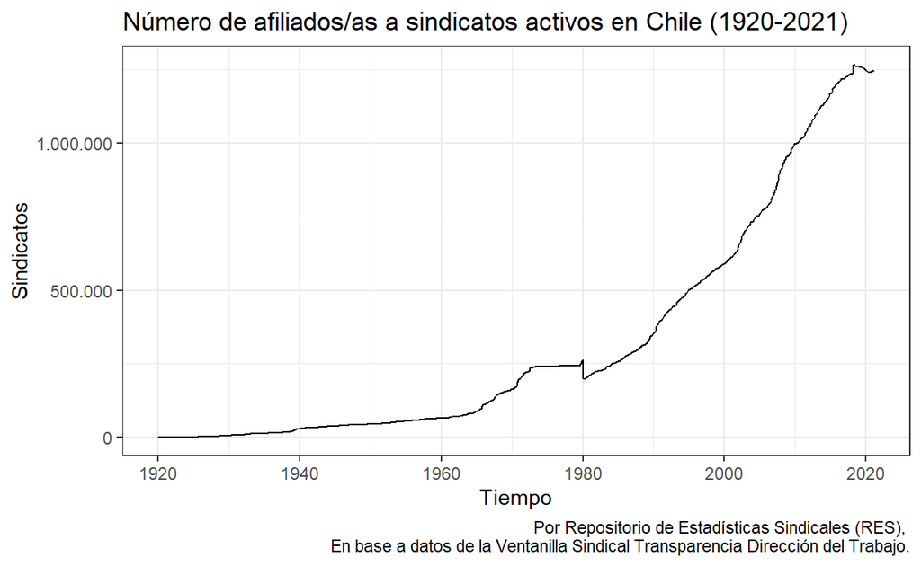

```r
wb <- createWorkbook()
addWorksheet(wb, sheetName = "base mensual afiliados", gridLines = TRUE)
writeData(wb = wb, sheet = "base mensual afiliados", x = afiliados)
firma<-c("Elaborado por Nicolás Ratto para Repositorio de Estadísticas Sindicales (RES): repositoriosindical.netlify.app/",
         "En base a datos de la ventanilla sindical de la Dirección del Trabajo: http://tramites.dirtrab.cl/VentanillaTransparencia/Transparencia/RerporteRRLLOrg.aspx") %>% as.data.frame()
writeData(wb = wb, sheet = "base mensual afiliados", x = firma,startCol = 9, startRow = 2)
saveWorkbook(wb = wb, file = "../OUTPUT/base mensual afiliados anidada.xlsx",
             overwrite = TRUE)


afiliados %>%
  ggplot(aes(x=fecha,y=Total))+geom_line()+theme_bw() +
    scale_y_continuous(labels=function(x) format(x, big.mark = ".", scientific = FALSE)) +
    labs(title = "Número de afiliados/as a sindicatos activos en Chile (1920-2021)",
       x="Tiempo",
       y = "Sindicatos",
       caption = "Por Repositorio de Estadísticas Sindicales (RES),
       En base a datos de la Ventanilla Sindical Transparencia Dirección del Trabajo.")
```

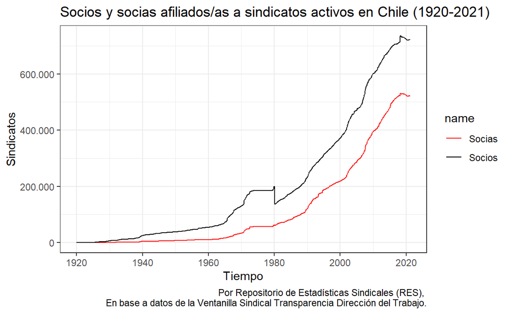

```r
ggsave(
  plot = last_plot(),
  filename = "../OUTPUT/Graficos/Nacionales/Grafico2_afiliados.png",
  device = "png",
  dpi = "retina",
  units = "cm",
  width = 25,
  height = 20
)

afiliados %>% select(fecha,Socios,Socias) %>% pivot_longer(cols = c(Socios,Socias)) %>%
    ggplot(aes(x=fecha,y=value,color=name))+geom_line()+theme_bw() +
    scale_y_continuous(labels=function(x) format(x, big.mark = ".", scientific = FALSE)) +
    labs(title = "Socios y socias afiliados/as a sindicatos activos en Chile (1920-2021)",
       x="Tiempo",
       y = "Sindicatos",
       caption = "Por Repositorio de Estadísticas Sindicales (RES),
       En base a datos de la Ventanilla Sindical Transparencia Dirección del Trabajo.") +
       scale_color_manual(values=c("red","black"))
```

```r
ggsave(
  plot = last_plot(),
  filename = "../OUTPUT/Graficos/Nacionales/Grafico2_afiliados_sexo.png",
  device = "png",
  dpi = "retina",
  units = "cm",
  width = 25,
  height = 20
)
```

# 4. Trabajadores afiliados por tipo de sindicato

```r
afiliados_tipo<-data.frame(1:nrow(fecha),
                      1:nrow(fecha),
                      1:nrow(fecha),
                      1:nrow(fecha),
                      1:nrow(fecha))

for(i in 1:nrow(sindicatos)){

  afiliados_tipo[i,] <- get(
    fecha[i,] %>% mutate(base=paste0("proxy_",ano,"_",mes)) %>% select(base) %>% as.character()
  ) %>% mutate(afiliados=Socios+Socias) %>% group_by(glosa1) %>% summarise(afiliados=sum(afiliados)) %>%
    pivot_wider(names_from = glosa1,values_from = afiliados)
}


afiliados_tipo<-afiliados_tipo %>% cbind(fecha) %>% mutate(fecha=ymd(paste0(ano,"-",mes,"-01")))

names(afiliados_tipo)<-c("SINDICATO EMPRESA","SINDICATO ESTABLECIMIENTO","SINDICATO INDEPENDIENTE","SINDICATO INTER EMPRESA",
                         "SINDICATO TRANSITORIO","ano","mes","fecha")
```

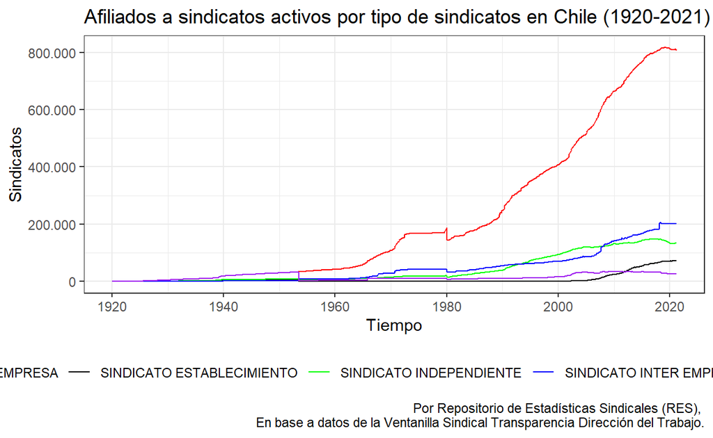

```r
wb <- createWorkbook()
addWorksheet(wb, sheetName = "base mensual afiliados_tipo", gridLines = TRUE)
writeData(wb = wb, sheet = "base mensual afiliados_tipo", x = afiliados_tipo)
firma<-c("Elaborado por Nicolás Ratto para Repositorio de Estadísticas Sindicales (RES): repositoriosindical.netlify.app/",
         "En base a datos de la ventanilla sindical de la Dirección del Trabajo: http://tramites.dirtrab.cl/VentanillaTransparencia/Transparencia/RerporteRRLLOrg.aspx") %>% as.data.frame()
writeData(wb = wb, sheet = "base mensual afiliados_tipo", x = firma,startCol = 11, startRow = 2)
saveWorkbook(wb = wb, file = "../OUTPUT/base mensual afiliados_tipo anidada.xlsx",
             overwrite = TRUE)

afiliados_tipo %>% select(fecha,1:5) %>% pivot_longer(2:6) %>%
    ggplot(aes(x=fecha,y=value,color=name))+geom_line()+theme_bw() +
    scale_y_continuous(labels=function(x) format(x, big.mark = ".", scientific = FALSE)) +
    labs(title = "Afiliados a sindicatos activos por tipo de sindicatos en Chile (1920-2021)",
       x="Tiempo",
       y = "Sindicatos",
       caption = "Por Repositorio de Estadísticas Sindicales (RES),
       En base a datos de la Ventanilla Sindical Transparencia Dirección del Trabajo.") +
       scale_color_manual(values=c("red","black","green","blue","purple")) +
  theme(legend.position = "bottom")
```

```r
ggsave(
  plot = last_plot(),
  filename = "../OUTPUT/Graficos/Nacionales/Grafico2_afiliados_tipo_sindicato.png",
  device = "png",
  dpi = "retina",
  units = "cm",
  width = 25,
  height = 20
)
```

# 5. Tasas de sindicalización

**Socios/as en noviembre de 2020**:

```r
afiliados_tipo %>% filter(fecha==ymd("2020-11-01")) %>%
  mutate(Total=`SINDICATO EMPRESA`+`SINDICATO ESTABLECIMIENTO`+`SINDICATO INDEPENDIENTE`+
           `SINDICATO INTER EMPRESA`+`SINDICATO TRANSITORIO`) %>% select(Total)
```

```
    Total
1 1243773
```

**Socios/as en noviembre de 2020 (sin considerar sindicatos de independientes**:

```r
afiliados_tipo %>% filter(fecha==ymd("2020-11-01")) %>%
  mutate(Total=`SINDICATO EMPRESA`+`SINDICATO ESTABLECIMIENTO`+
           `SINDICATO INTER EMPRESA`+`SINDICATO TRANSITORIO`) %>% select(Total)
```

```
    Total
1 1110698
```

Con estas dos cifras es posible calcular las tres tasas de sindicalización que la Dirección del Trabajo publica en sus compendios. En tanto la cifra para el año 2020 aún no esta disponible, considerando los datos del INE ya publicados, estas cifras se pueden adelantar. En términos generales, para la construcción de las tasas sindicales, la Dirección del Trabajo divide sus indicadores de afiliados y afiliadas a sindicatos por las estimaciones de ocupados en el trimestre Octubre-Diciembre (OND) del Instituto Nacional de Estadística.

## A. Tasa de sindicalización respecto de los ocupados:

“Esta tasa incluye en su cálculo trabajadores no afectos a sindicalizarse, no obstante facilita establecer comparaciones internacionales”.

$ts_{1}={PoblaciónAfiliada/ft_{ocupada1}}$

Donde: $ft_{ocupada1}$: Fuerza de trabajo ocupada en trimestre OND.

## B. Tasa de sindicalización respecto de los ocupados con posibilidad de sindicalizarse:

“Incluye a los asalariados del sector privado, personal de servicio doméstico y trabajadores por cuenta propia. Excluye a asalariados del sector público.”

$ts_{2}={PoblaciónAfiliada/ft_{ocupada2}}$

$ft_{ocupada2}$: Categoría de Ocupados, menos independientes empleadores, independientes familiares no remunerados y asalariados sector público.

## C. Tasa de sindicalización respecto de los asalariados con posibilidad de sindicalizarse:

“Incluye asalariados del sector privado y personal de servicio doméstico. Excluye a asalariados del sector público. No considera sindicatos independientes.”

$ts_{3}={PoblaciónAfiliadaDependiente/ft_{ocupada3}}$

$ft_{ocupada3}$: asalariados sector privado y personal de servicio domestico (puertas afuera y puertas adentro)

Descarga datos INE:

```r
categoria_ocupacion<-read.xlsx("http://www.ine.cl/docs/default-source/ocupacion-y-desocupacion/cuadros-estadisticos/series-de-tiempo-nueva-calibraci%C3%B3n-proyecciones-de-poblaci%C3%B3n-censo-2017/serie-categor%C3%ADa-en-la-ocupaci%C3%B3n.xlsx?sfvrsn=70dc54db_24",sheet = 2,startRow = 6)
nombres<-names(categoria_ocupacion)
categoria_ocupacion<-read.xlsx("http://www.ine.cl/docs/default-source/ocupacion-y-desocupacion/cuadros-estadisticos/series-de-tiempo-nueva-calibraci%C3%B3n-proyecciones-de-poblaci%C3%B3n-censo-2017/serie-categor%C3%ADa-en-la-ocupaci%C3%B3n.xlsx?sfvrsn=70dc54db_24", sheet = 2,startRow = 7)
categoria_ocupacion<-categoria_ocupacion[1:(nrow(categoria_ocupacion)-9),c(1,2,4,6,8,10,12,14,16,18,20,22,24,26)]
nombres<-nombres[c(1,2,4-1,6-1,8-1,10-1,12-1,14-1,16-1,18-1,20-1,22-1,24-1,26-1)]
names(categoria_ocupacion)<-nombres

categoria_ocupacion<-categoria_ocupacion %>% filter(Trimestre=="Oct - Dic")

categoria_ocupacion<-categoria_ocupacion %>%

  mutate(ft_ocupada1=Total.de.ocupados*1000,

         ft_ocupada2=(Total.de.ocupados-`Independientes.(Empleadores)`-
            `Independientes.(Familiares.no.remunerados)`-`Asalariado.(Sector.público)./5`)*1000,

  ft_ocupada3=(`Asalariados.(Sector.privado)`+ `Personal.de.servicio.doméstico.(Total)./6`)*1000)


categoria_ocupacion<-afiliados_tipo %>% filter(fecha>=ymd("2010-11-01")) %>%
  filter(month(fecha)==11) %>%
  mutate(s1=`SINDICATO EMPRESA`+`SINDICATO ESTABLECIMIENTO`+`SINDICATO INDEPENDIENTE`+
           `SINDICATO INTER EMPRESA`+`SINDICATO TRANSITORIO`) %>% select(s1) %>% mutate(s2=s1) %>% cbind(categoria_ocupacion)

categoria_ocupacion<-afiliados_tipo %>% filter(fecha>=ymd("2010-11-01")) %>%
  filter(month(fecha)==11) %>%
  mutate(s3=`SINDICATO EMPRESA`+`SINDICATO ESTABLECIMIENTO`+
           `SINDICATO INTER EMPRESA`+`SINDICATO TRANSITORIO`) %>% select(s3) %>% cbind(categoria_ocupacion)

categoria_ocupacion<-categoria_ocupacion %>% mutate(ts1=s1/ft_ocupada1*100,
                               ts2=s2/ft_ocupada2*100,
                               ts3=s3/ft_ocupada3*100)
```

En tanto la cifra para el año 2020 aún no esta disponible, considerando los datos del INE, se puede adelantar que las tasas 1, 2 y 3 serán, respectivamente: 15.4963797%, 18.9163498% y 22.2719325%.

El aumento en las 3 tasas respecto de 2019 se explica por la fuerte caída del empleo en el año 2020 por efecto del Covid-19.

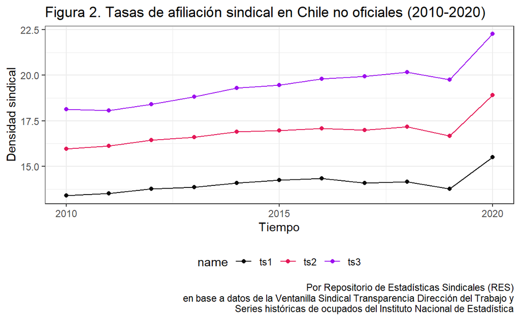

```r
categoria_ocupacion %>%
  mutate(Año=make_date(year=Año)) %>%
  select(Año,ts1,ts2,ts3) %>% pivot_longer(c(ts1,ts2,ts3)) %>%
  ggplot(aes(x=Año,y=value,color=name)) + geom_line() + geom_point() +theme_bw() +
    labs(title = "Figura 2. Tasas de afiliación sindical en Chile no oficiales (2010-2020)",
       x="Tiempo",
       y = "Densidad sindical",
      caption = "Por Repositorio de Estadísticas Sindicales (RES)
       en base a datos de la Ventanilla Sindical Transparencia Dirección del Trabajo y
       Series históricas de ocupados del Instituto Nacional de Estadística") +
       scale_color_manual(values=colores_res) +
  theme(legend.position = "bottom")
```

```r
ggsave(
  plot = last_plot(),
  filename = "../OUTPUT/Graficos/Nacionales/tasaafiliacionsindical_nooficiales.png",
  device = "png",
  dpi = "retina",
  units = "cm",
  width = 20,
  height = 15
)

categoria_ocupacion %>%
  select(Año,ts1,ts2,ts3,s1,ft_ocupada1,s2,ft_ocupada2,s3,ft_ocupada3) %>% knitr::kable()
```

| Año | ts1 | ts2 | ts3 | s1 | ft_ocupada1 | s2 | ft_ocupada2 | s3 | ft_ocupada3 |
| --- | --- | --- | --- | --- | --- | --- | --- | --- | --- |
| 2010 | 13.39208 | 15.96325 | 18.13350 | 1014091 | 7572318 | 1014091 | 6352659 | 882437 | 4866337 |
| 2011 | 13.51170 | 16.12482 | 18.06397 | 1052143 | 7786902 | 1052143 | 6524992 | 918061 | 5082278 |
| 2012 | 13.75676 | 16.44400 | 18.41633 | 1093973 | 7952257 | 1093973 | 6652717 | 959353 | 5209253 |
| 2013 | 13.84992 | 16.60122 | 18.81853 | 1128684 | 8149389 | 1128684 | 6798801 | 991852 | 5270614 |
| 2014 | 14.08535 | 16.89690 | 19.29981 | 1161988 | 8249620 | 1161988 | 6876931 | 1019599 | 5282949 |
| 2015 | 14.24422 | 16.97752 | 19.45831 | 1200570 | 8428470 | 1200570 | 7071526 | 1054316 | 5418333 |
| 2016 | 14.33710 | 17.08375 | 19.79832 | 1218755 | 8500710 | 1218755 | 7134002 | 1070296 | 5405994 |
| 2017 | 14.08511 | 16.99871 | 19.93582 | 1235076 | 8768667 | 1235076 | 7265703 | 1087286 | 5453933 |
| 2018 | 14.14976 | 17.17241 | 20.16289 | 1261345 | 8914248 | 1261345 | 7345184 | 1116764 | 5538711 |
| 2019 | 13.77239 | 16.67041 | 19.76027 | 1251515 | 9087132 | 1251515 | 7507403 | 1115615 | 5645747 |
| 2020 | 15.49638 | 18.91635 | 22.27193 | 1243773 | 8026217 | 1243773 | 6575122 | 1110698 | 4986985 |

```r
writexl::write_xlsx(categoria_ocupacion,"../OUTPUT/Minuta1/tasas.xlsx")
```

# 6. Zoom a Octubre 2019 y Pandemia

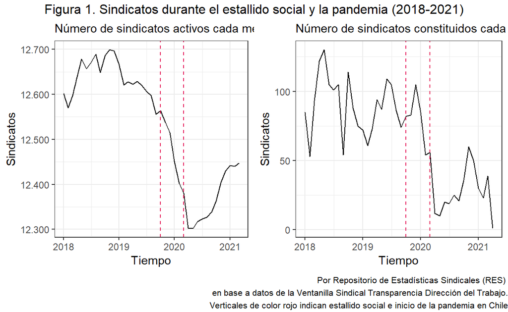

```r
library(ggpubr)

base<-read_excel("../INPUT/archivo_sindicatos_limpia.xlsx")

g1<-base %>% mutate(FechaConstitucion=ymd(FechaConstitucion) ) %>%
  filter(FechaConstitucion>=ymd("2018-01-01")) %>%
  mutate(ano_constitucion=year(FechaConstitucion),mes_constitucion=month(FechaConstitucion)) %>%
  group_by(ano_constitucion,mes_constitucion) %>% summarise(sindicatos_constituidos=n()) %>%
  mutate(FechaConstitucion=make_date(year=ano_constitucion,month=mes_constitucion)) %>%
  ggplot(aes(x=FechaConstitucion,y=sindicatos_constituidos))+geom_line()+theme_bw() +
    scale_y_continuous(labels=function(x) format(x, big.mark = ".", scientific = FALSE)) +
    labs(subtitle = "Número de sindicatos constituidos cada mes",
       x="Tiempo",
       y = "Sindicatos") +
  geom_vline(xintercept = ymd("2019-10-01"),linetype = "dashed", colour = "#E41657") +
  geom_vline(xintercept = ymd("2020-03-01"),linetype = "dashed", colour = "#E41657")

g2<-sindicatos %>% filter(fecha>=ymd("2018-01-01")) %>%
  ggplot(aes(x=fecha,y=sindicatos))+geom_line()+theme_bw() +
    scale_y_continuous(labels=function(x) format(x, big.mark = ".", scientific = FALSE)) +
    labs(subtitle = "Número de sindicatos activos cada mes",
         x="Tiempo",
       y = "Sindicatos") +
  geom_vline(xintercept = ymd("2019-10-01"),linetype = "dashed", colour = "#E41657") +
  geom_vline(xintercept = ymd("2020-03-01"),linetype = "dashed", colour = "#E41657")

ggarrange(g2,g1,ncol = 2,common.legend = TRUE) %>%
  annotate_figure(top = text_grob("Figura 1. Sindicatos durante el estallido social y la pandemia (2018-2021)",
                                  color = "black",  size = 12),
               bottom = text_grob("Por Repositorio de Estadísticas Sindicales (RES)
       en base a datos de la Ventanilla Sindical Transparencia Dirección del Trabajo.
       Verticales de color rojo indican estallido social e inicio de la pandemia en Chile",
       color = "black", hjust = 1, x = 1, size = 8))
```

```r
ggsave(
  plot = last_plot(),
  filename = "../OUTPUT/Graficos/Nacionales/Grafico2018-2021.png",
  device = "png",
  dpi = "retina",
  units = "cm",
  width = 20,
  height = 15
)

tab1.1<-sindicatos %>% filter(fecha>=ymd("2010-01-01"))

tab1.2<-base %>% mutate(FechaConstitucion=ymd(FechaConstitucion) ) %>%
  filter(FechaConstitucion>=ymd("2018-01-01")) %>%
  mutate(ano_constitucion=year(FechaConstitucion),mes_constitucion=month(FechaConstitucion)) %>%
  group_by(ano_constitucion,mes_constitucion) %>% summarise(sindicatos_constituidos=n()) %>%
  mutate(FechaConstitucion=make_date(year=ano_constitucion,month=mes_constitucion))

writexl::write_xlsx(list("activos"=tab1.1,"constituidos"=tab1.2),"../OUTPUT/Minuta1/tabla1.xlsx")

writexl::write_xlsx(proxy_2021_3,"../OUTPUT/Minuta1/BBDD_sindicatos_activos.xlsx")
```

# Otros zoom al estallido y la pandemia

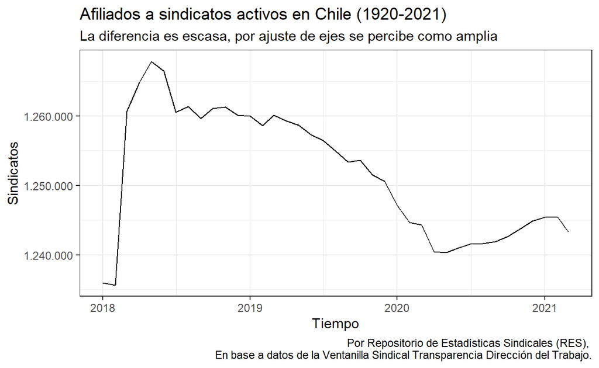

```r
afiliados %>%
  filter(fecha>=ymd("2018-01-01")) %>%
  select(fecha,Total) %>%
    ggplot(aes(x=fecha,y=Total))+geom_line()+theme_bw() +
    scale_y_continuous(labels=function(x) format(x, big.mark = ".", scientific = FALSE)) +
    labs(title = "Afiliados a sindicatos activos en Chile (1920-2021)",
         subtitle = "La diferencia es escasa, por ajuste de ejes se percibe como amplia",
       x="Tiempo",
       y = "Sindicatos",
       caption = "Por Repositorio de Estadísticas Sindicales (RES),
       En base a datos de la Ventanilla Sindical Transparencia Dirección del Trabajo.")
```

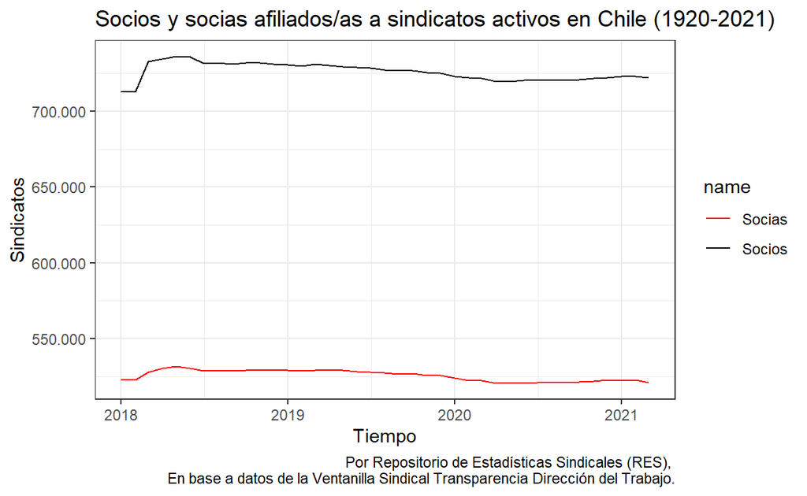

```r
afiliados %>%
  filter(fecha>=ymd("2018-01-01")) %>%
  select(fecha,Socios,Socias) %>% pivot_longer(cols = c(Socios,Socias)) %>%
    ggplot(aes(x=fecha,y=value,color=name))+geom_line()+theme_bw() +
    scale_y_continuous(labels=function(x) format(x, big.mark = ".", scientific = FALSE)) +
    labs(title = "Socios y socias afiliados/as a sindicatos activos en Chile (1920-2021)",
       x="Tiempo",
       y = "Sindicatos",
       caption = "Por Repositorio de Estadísticas Sindicales (RES),
       En base a datos de la Ventanilla Sindical Transparencia Dirección del Trabajo.") +
       scale_color_manual(values=c("red","black"))
```

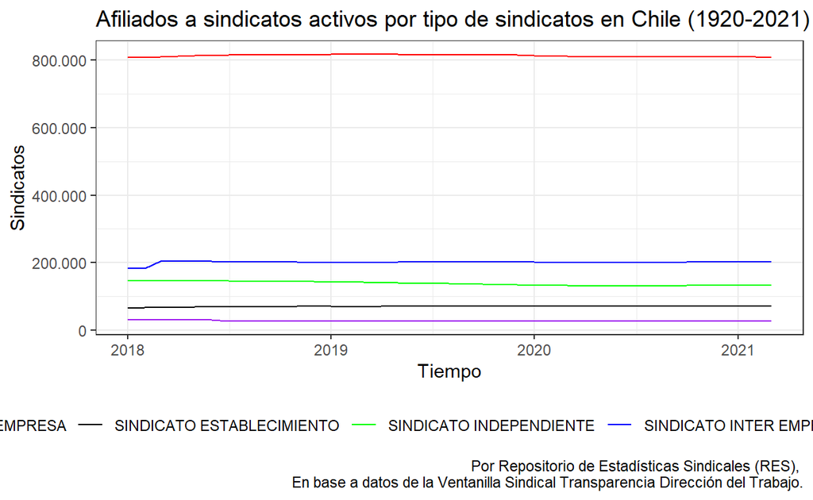

```r
afiliados_tipo%>%
  filter(fecha>=ymd("2018-01-01")) %>%
 select(fecha,1:5) %>% pivot_longer(2:6) %>%
    ggplot(aes(x=fecha,y=value,color=name))+geom_line()+theme_bw() +
    scale_y_continuous(labels=function(x) format(x, big.mark = ".", scientific = FALSE)) +
    labs(title = "Afiliados a sindicatos activos por tipo de sindicatos en Chile (1920-2021)",
       x="Tiempo",
       y = "Sindicatos",
       caption = "Por Repositorio de Estadísticas Sindicales (RES),
       En base a datos de la Ventanilla Sindical Transparencia Dirección del Trabajo.") +
       scale_color_manual(values=c("red","black","green","blue","purple")) +
  theme(legend.position = "bottom")
```

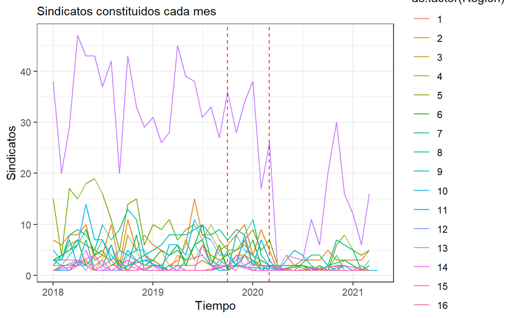

```r
base %>% mutate(FechaConstitucion=ymd(FechaConstitucion) ) %>%
  filter(FechaConstitucion>=ymd("2018-01-01")) %>%
  mutate(ano_constitucion=year(FechaConstitucion),mes_constitucion=month(FechaConstitucion)) %>%
  group_by(ano_constitucion,mes_constitucion,Region) %>%
  summarise(sindicatos_constituidos=n()) %>%
  mutate(FechaConstitucion=make_date(year=ano_constitucion,month=mes_constitucion)) %>%

  ggplot(aes(x=FechaConstitucion,y=sindicatos_constituidos,color=as.factor(Region)))+geom_line()+theme_bw() +
    scale_y_continuous(labels=function(x) format(x, big.mark = ".", scientific = FALSE)) +
    labs(subtitle = "Sindicatos constituidos cada mes",
       x="Tiempo",
       y = "Sindicatos") +
  geom_vline(xintercept = ymd("2019-10-01"),linetype = "dashed", colour = "red") +
  geom_vline(xintercept = ymd("2020-03-01"),linetype = "dashed", colour = "red")
```

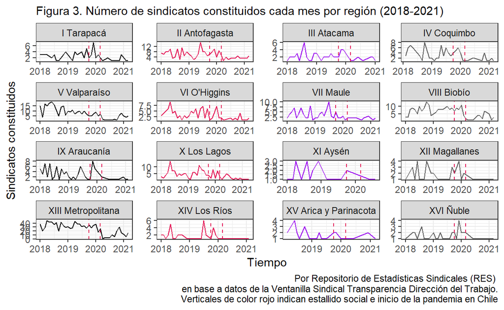

```r
 base$reRegion <- factor(base$Region, levels = c(1,2,3,4,5,6,7,8,9,10,11,12,13,14,15,16), labels = c("I Tarapacá", "II Antofagasta", "III Atacama", "IV Coquimbo", "V Valparaíso", "VI O'Higgins", "VII Maule", "VIII Biobío", "IX Araucanía", "X Los Lagos", "XI Aysén", "XII Magallanes", "XIII Metropolitana", "XIV Los Ríos", "XV Arica y Parinacota", "XVI Ñuble")) # mantengo variable original

base %>% mutate(FechaConstitucion=ymd(FechaConstitucion) ) %>%
  filter(FechaConstitucion>=ymd("2018-01-01")) %>%
  mutate(ano_constitucion=year(FechaConstitucion),mes_constitucion=month(FechaConstitucion)) %>%
  group_by(ano_constitucion,mes_constitucion,reRegion) %>%
  summarise(sindicatos_constituidos=n()) %>%
  mutate(FechaConstitucion=make_date(year=ano_constitucion,month=mes_constitucion)) %>%

  ggplot(aes(x=FechaConstitucion,y=sindicatos_constituidos,color=as.factor(reRegion)))+geom_line()+
  facet_wrap(~as.factor(reRegion),scales = "free")+
  theme_bw() +
    scale_y_continuous(labels=function(x) format(x, big.mark = ".", scientific = FALSE)) +
    labs(subtitle = "Figura 3. Número de sindicatos constituidos cada mes por región (2018-2021)",
       x="Tiempo",
       y = "Sindicatos constituidos",
       caption = "Por Repositorio de Estadísticas Sindicales (RES)
       en base a datos de la Ventanilla Sindical Transparencia Dirección del Trabajo.
       Verticales de color rojo indican estallido social e inicio de la pandemia en Chile") +
  scale_color_manual(values=c(rep(colores_res,4))) +
  geom_vline(xintercept = ymd("2019-10-01"),linetype = "dashed", colour = "#E41657") +
  geom_vline(xintercept = ymd("2020-03-01"),linetype = "dashed", colour = "#E41657") +
  theme(legend.position = "none")
```

```r
ggsave(
  plot = last_plot(),
  filename = "../OUTPUT/Graficos/Nacionales/Constituidos_region_2018-2021.png",
  device = "png",
  dpi = "retina",
  units = "cm",
  width = 20,
  height = 15
)
```